```r
x <- c(150, 160, 170, 180, 190)
y <- c(176, 179, 182, 181, 185)
# 회귀식 추정
lm(y~x)
```

```
##
## Call:
## lm(formula = y ~ x)
##
## Coefficients:
## (Intercept)            x
##       146.6          0.2
```

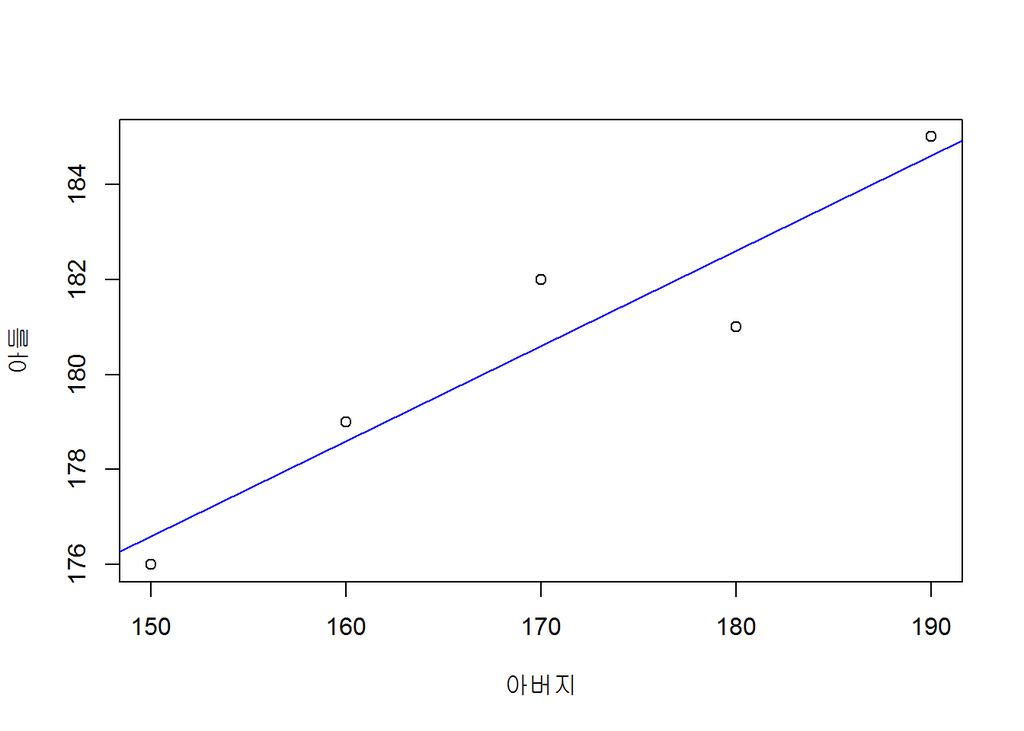

```r
# 산점도 그리기
m1 <- lm(y~x)
plot(y~x,xlab='아버지',ylab='아들')
abline(m1,col='blue')
```

```r
# F-statisic - 도출된 회귀식이 회귀분석 모델전체에 대해 통계적으로 의미가 있는지 파악

# P - Value - 변수가 종속변수에 미치는 영향은 유의한가
# 수정된R 제곱
summary(m1)
```

```
##
## Call:
## lm(formula = y ~ x)
##
## Residuals:
##    1    2    3    4    5
## -0.6  0.4  1.4 -1.6  0.4
##
## Coefficients:
##              Estimate Std. Error t value Pr(>|t|)
## (Intercept) 146.60000    7.10211  20.642 0.000249 ***
## x             0.20000    0.04163   4.804 0.017171 *
## ---
## Signif. codes:  0 '***' 0.001 '**' 0.01 '*' 0.05 '.' 0.1 ' ' 1
##
## Residual standard error: 1.317 on 3 degrees of freedom
## Multiple R-squared:  0.885,  Adjusted R-squared:  0.8466
## F-statistic: 23.08 on 1 and 3 DF,  p-value: 0.01717
```

- p-value: 0.01717 의 값이 0.05보다 작기에 이 회귀식은 회귀분석 모델전체에 대해 통계적으로 의미가 있다고 볼 수 있다.
- Adjusted R-squared: 0.8466 으로써 84.6% 만큼의 설명력을 가진다고 판단할 수 있습니다.

```r
x <- c(100, 200, 300, 400, 500)
y <- c(30, 70, 85, 140, 197)
# 회귀식 추정
lm(y~x)
```

```
##
## Call:
## lm(formula = y ~ x)
##
## Coefficients:
## (Intercept)            x
##     -16.800        0.404
```

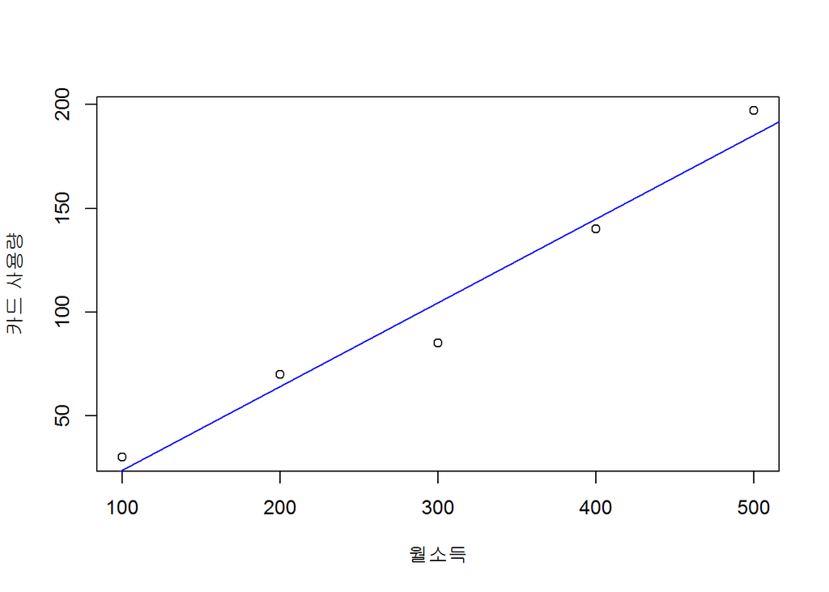

```r
# 산점도 그리기
m1 <- lm(y~x)
plot(y~x,xlab='월소득',ylab='카드 사용량')
abline(m1,col='blue')
```

```r
# F-statisic - 도출된 회귀식이 회귀분석 모델전체에 대해 통계적으로 의미가 있는지 파악

# P - Value - 변수가 종속변수에 미치는 영향은 유의한가
# 수정된R 제곱
summary(m1)
```

```
##
## Call:
## lm(formula = y ~ x)
##
## Residuals:
##     1     2     3     4     5
##   6.4   6.0 -19.4  -4.8  11.8
##
## Coefficients:
##             Estimate Std. Error t value Pr(>|t|)
## (Intercept) -16.8000    15.0240  -1.118  0.34495
## x             0.4040     0.0453   8.919  0.00297 **
## ---
## Signif. codes:  0 '***' 0.001 '**' 0.01 '*' 0.05 '.' 0.1 ' ' 1
##
## Residual standard error: 14.32 on 3 degrees of freedom
## Multiple R-squared:  0.9637, Adjusted R-squared:  0.9515
## F-statistic: 79.54 on 1 and 3 DF,  p-value: 0.002974
```

- p-value: 0.002974 의 값이 0.05보다 작기에 이 회귀식은 회귀분석 모델전체에 대해 통계적으로 의미가 있다고 볼 수 있다.
- Adjusted R-squared: 0.9515 으로써 95.1% 만큼의 설명력을 가진다고 판단할 수 있습니다.

#### 3.mtcars의 배기량(disp)에 따른 마력(hp)의 회귀식

```r
# mtcars
# View(mtcars)
#head(mtcars)
# str(mtcars)
out<- lm(hp~disp, data=mtcars)
summary(out)
```

```
##
## Call:
## lm(formula = hp ~ disp, data = mtcars)
##
## Residuals:
##     Min      1Q  Median      3Q     Max
## -48.623 -28.378  -6.558  13.588 157.562
##
## Coefficients:
##             Estimate Std. Error t value Pr(>|t|)
## (Intercept)  45.7345    16.1289   2.836  0.00811 **
## disp          0.4375     0.0618   7.080 7.14e-08 ***
## ---
## Signif. codes:  0 '***' 0.001 '**' 0.01 '*' 0.05 '.' 0.1 ' ' 1
##
## Residual standard error: 42.65 on 30 degrees of freedom
## Multiple R-squared:  0.6256, Adjusted R-squared:  0.6131
## F-statistic: 50.13 on 1 and 30 DF,  p-value: 7.143e-08
```